# R GBM walkthrough

Evan Muzzall

November 18, 2016

# 0. Freund and Schapire 1999 - background

From [Freund and Schapire 1999](https://cseweb.ucsd.edu/~yfreund/papers/IntroToBoosting.pdf). “Boosting is a general method for improving the accuracy of any given learning algorithm” and originated in the AdaBoost and PAC learning (p. 1-2). Gradient boosted machines are ensembles decision tree methods of “weak” trees that are just slightly more accurate than random guessing which are then “boosted” into “strong” learners. That is, the models don’t have to be accurate over the entire feature space.

The model first tried to predict each value in a dataset - the cases that can be predicted easily are *downweighted* so that the algorithm does not have to try as hard to predic them.

However, the cases that the model has difficulty predicting are *upweighted* so that the model tries more assertively to predict them. This continues for multiple “boosting” iterations. A resample-based performance measure is produced at each iteration. Error is measured on the weak learners so that even performing slightly better than random guessing improves accuracy fast (p.2). This method can drive down generalization error thus preventing overfitting (p. 5). While it is susceptible to noise, it is robust to outlier detection.

# 1. install packages

```r
install.packages("car", dependencies=TRUE)
install.packages("caret", dependencies=TRUE)
install.packages("pROC", dependencies=TRUE)
```

```r
library(car)
library(caret)
library(pROC)
```

# 2. load the Mroz dataset

```r
library(car)
data(Mroz)
str(Mroz)
```

```
## 'data.frame':    753 obs. of  8 variables:
##  $ lfp : Factor w/ 2 levels "no","yes": 2 2 2 2 2 2 2 2 2 2 ...
##  $ k5  : int  1 0 1 0 1 0 0 0 0 0 ...
##  $ k618: int  0 2 3 3 2 0 2 0 2 2 ...
##  $ age : int  32 30 35 34 31 54 37 54 48 39 ...
##  $ wc  : Factor w/ 2 levels "no","yes": 1 1 1 1 2 1 2 1 1 1 ...
##  $ hc  : Factor w/ 2 levels "no","yes": 1 1 1 1 1 1 1 1 1 1 ...
##  $ lwg : num  1.2102 0.3285 1.5141 0.0921 1.5243 ...
##  $ inc : num  10.9 19.5 12 6.8 20.1 ...
```

### 2.1 See variable definitions with `?Mroz`

# 3. use createDataPartition() to create an 75/25 stratified random split

```r
library(caret)
split <- createDataPartition(Mroz$lfp, p=0.75, list=FALSE)
training.set <- Mroz[split,]
test.set <- Mroz[-split,]
nrow(training.set) + nrow(test.set) == nrow(Mroz) # sanity check
```

```
## [1] TRUE
```

`createDataPartition` = creates a stratified random split training.set = train model here test.set = does trained model maintain its performance here?

# 4. train() a GBM model

```r
set.seed(1)
gbm.fit1 <- train(lfp ~ ., data=training.set, method="gbm", verbose=FALSE)
```

`train()` holds the tuning parameters; fits each one then calculates a resampling based performance metric

" . " comes from Perl’s regex library and stands for “everything else”.

### 4.1 model summary

View a model summary table by calling the object. caret shows us the optimal model based on its attributes

```r
gbm.fit1
```

```
## Stochastic Gradient Boosting
##
## 565 samples
##   7 predictor
##   2 classes: 'no', 'yes'
##
## No pre-processing
## Resampling: Bootstrapped (25 reps)
## Summary of sample sizes: 565, 565, 565, 565, 565, 565, ...
## Resampling results across tuning parameters:
##
##   interaction.depth  n.trees  Accuracy   Kappa
##   1                   50      0.7109239  0.4050849
##   1                  100      0.7203181  0.4260104
##   1                  150      0.7197835  0.4250399
##   2                   50      0.7270639  0.4407078
##   2                  100      0.7349059  0.4561485
##   2                  150      0.7347053  0.4568769
##   3                   50      0.7342505  0.4546545
##   3                  100      0.7387058  0.4655105
##   3                  150      0.7389972  0.4666268
##
## Tuning parameter 'shrinkage' was held constant at a value of 0.1
##
## Tuning parameter 'n.minobsinnode' was held constant at a value of 10
## Accuracy was used to select the optimal model using  the largest value.
## The final values used for the model were n.trees = 150,
##  interaction.depth = 3, shrinkage = 0.1 and n.minobsinnode = 10.
```

### 4.2 Plot bargraph of variable relative influence with summary()

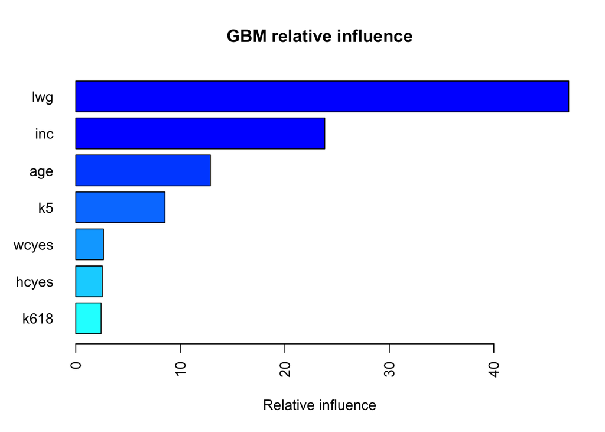

```
##         var   rel.inf
## lwg     lwg 47.165074
## inc     inc 23.820847
## age     age 12.878184
## k5       k5  8.531986
## wcyes wcyes  2.646484
## hcyes hcyes  2.534099
## k618   k618  2.423327
```

```r
summary(gbm.fit1, las=2, main="GBM relative influence")
```

```r
gbm.fit1$times
```

```
## $everything
##    user  system elapsed
##   3.509   0.036   3.562
##
## $final
##    user  system elapsed
##   0.037   0.000   0.037
##
## $prediction
## [1] NA NA NA
```

# 5. trainControl() and expand.grid()

### 5.1 define the parameters of the control mechanism with `trainControl()`

```r
control <- trainControl(method="repeatedcv",
    repeats=5,
    classProbs=TRUE,
    summaryFunction=twoClassSummary)
```

method = “repeatedcv”: CV measures predictive performance of a statistical model; repeats = number of times to repeat the cross-validation classProbs = this will calculate predicted class probabilities (ROC) within the resampling process (Kuhn, 2015:4) summaryFunction = uses observed versus predicted values to estimate performance (AUC, sensitivity, specificity) (Kuhn, 2015:4)

### 5.2 compare multiple models at once with `expand.grid()`

```r
grid <- expand.grid(n.trees=seq(100,2100, by=100),
    interaction.depth=seq(1,3,5),
    shrinkage=c(0.01,0.05, 0.1),
    n.minobsinnode=10)
```

shrinkage = learning rate of the algorithm; how quickly the model adapts to the data at each iteration n.minobsinnode = minimum number of observations needed to commence splitting

n.trees = number of boosting iterations interaction.depth = tree depth/complexity shrinkage = learning rate of the model; how quickly it adapts at each iteration n.minobsinnode = minimum number of samples needed to commence splitting

```r
set.seed(1)
gbm.fit2 <- train(lfp ~ ., data=training.set,
    method="gbm",
    metric="ROC",
    trControl=control,
    tuneGrid=grid,
    verbose=FALSE)
gbm.fit2$times
```

```
## $everything
##    user  system elapsed
##  37.685   0.057  37.754
##
## $final
##    user  system elapsed
##   0.093   0.000   0.093
##
## $prediction
## [1] NA NA NA
```

verbose = print lengthy output (`TRUE` or `FALSE`?)

### 5.3 model summary table

```r
gbm.fit2
```

```
## Stochastic Gradient Boosting
##
## 565 samples
##   7 predictor
##   2 classes: 'no', 'yes'
##
## No pre-processing
## Resampling: Cross-Validated (10 fold, repeated 5 times)
## Summary of sample sizes: 509, 509, 508, 508, 507, 509, ...
## Resampling results across tuning parameters:
##
##   shrinkage  n.trees  ROC        Sens       Spec
##   0.01        100     0.7557503  0.3364667  0.8749242
##   0.01        200     0.7744033  0.6376333  0.7408902
##   0.01        300     0.7853781  0.6555333  0.7539015
##   0.01        400     0.7914835  0.6587000  0.7657386
##   0.01        500     0.7968627  0.6605667  0.7751136
##   0.01        600     0.7994810  0.6596667  0.7738447
##   0.01        700     0.8009363  0.6686667  0.7744508
##   0.01        800     0.8031121  0.6661667  0.7713068
##   0.01        900     0.8030480  0.6637333  0.7706629
##   0.01       1000     0.8035009  0.6662000  0.7675568
##   0.01       1100     0.8041298  0.6662333  0.7675379
##   0.01       1200     0.8040498  0.6735667  0.7644318
##   0.01       1300     0.8050611  0.6735000  0.7681818
##   0.01       1400     0.8054229  0.6727333  0.7700379
##   0.01       1500     0.8057559  0.6711333  0.7706061
##   0.01       1600     0.8058013  0.6703000  0.7699811
##   0.01       1700     0.8063095  0.6703667  0.7724811
##   0.01       1800     0.8066954  0.6711000  0.7718561
##   0.01       1900     0.8060028  0.6686333  0.7693561
##   0.01       2000     0.8056206  0.6710333  0.7712121
##   0.01       2100     0.8058793  0.6702333  0.7724621
##   0.05        100     0.7938262  0.6669333  0.7638447
##   0.05        200     0.8007723  0.6719667  0.7669508
##   0.05        300     0.8035762  0.6760667  0.7662689
##   0.05        400     0.8049132  0.6751667  0.7644129
##   0.05        500     0.8051277  0.6776000  0.7668939
##   0.05        600     0.8050305  0.6792667  0.7700000
##   0.05        700     0.8057092  0.6710667  0.7650189
```

[output cut: 27 more lines]

```
##   0.10       1400     0.8069296  0.6809667  0.7662879
##   0.10       1500     0.8060618  0.6817333  0.7669129
##   0.10       1600     0.8066188  0.6884000  0.7706629
##   0.10       1700     0.8054460  0.6802333  0.7706439
##   0.10       1800     0.8046436  0.6803333  0.7725000
##   0.10       1900     0.8043692  0.6866000  0.7693561
##   0.10       2000     0.8033734  0.6826333  0.7693750
##   0.10       2100     0.8019973  0.6858667  0.7687121
##
## Tuning parameter 'interaction.depth' was held constant at a value of
##  1
## Tuning parameter 'n.minobsinnode' was held constant at a value of 10
## ROC was used to select the optimal model using  the largest value.
## The final values used for the model were n.trees = 800,
##  interaction.depth = 1, shrinkage = 0.1 and n.minobsinnode = 10.
```

### 5.4 bargraph of variable relative influence

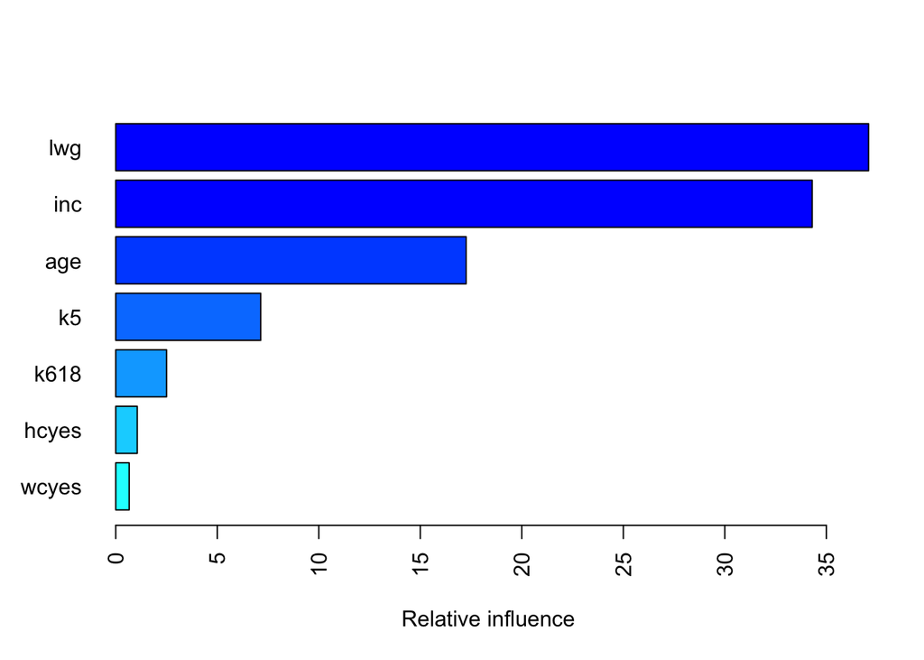

```
##         var    rel.inf
## lwg     lwg 37.0790395
## inc     inc 34.3029346
## age     age 17.2587856
## k5       k5  7.1393582
## k618   k618  2.5025734
## hcyes hcyes  1.0576840
## wcyes wcyes  0.6596247
```

```r
summary(gbm.fit2, las=2)
```

# 6. ggplot line graph of the tunded models

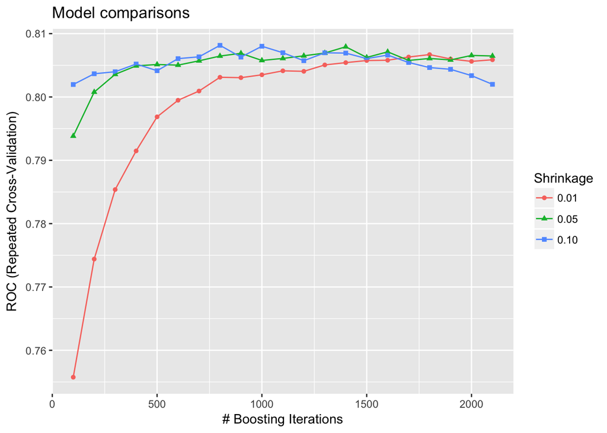

```r
ggplot(gbm.fit2) + theme_grey() + ggtitle("Model comparisons")
```

Want to learn more about ggplot2 themes? :) See [the ggplot2 themes help page](http://docs.ggplot2.org/dev/vignettes/themes.html)

# 7. generate GBM predicted values and probabilities with with `predict()`

```r
set.seed(1)
gbm.pred <- predict(gbm.fit2, test.set)
gbm.prob <- predict(gbm.fit2, test.set, type="prob")
```

`predict()` = predictions of various model fitting functions

### 7.1 view GBM final model

```r
gbm.cm <- confusionMatrix(gbm.pred, test.set$lfp)
gbm.cm
```

```
## Confusion Matrix and Statistics
##
##           Reference
## Prediction no yes
##        no  59  30
##        yes 22  77
##
##                Accuracy : 0.7234
##                  95% CI : (0.6536, 0.786)
##     No Information Rate : 0.5691
##     P-Value [Acc > NIR] : 8.878e-06
##
##                   Kappa : 0.4427
##  Mcnemar's Test P-Value : 0.3317
##
##             Sensitivity : 0.7284
##             Specificity : 0.7196
##          Pos Pred Value : 0.6629
##          Neg Pred Value : 0.7778
##              Prevalence : 0.4309
##          Detection Rate : 0.3138
##    Detection Prevalence : 0.4734
##       Balanced Accuracy : 0.7240
##
##        'Positive' Class : no
##
```

A confusion/error matrix is a cross-tabulation of observed versus predicted classes

# 8. plot GBM ROC curve

```r
library(pROC)
```

```r
rocCurve <- roc(response=test.set$lfp,
    predictor = gbm.prob[, "yes"],
    levels = rev(levels(test.set$lfp)),
    auc=TRUE, ci=TRUE)
```

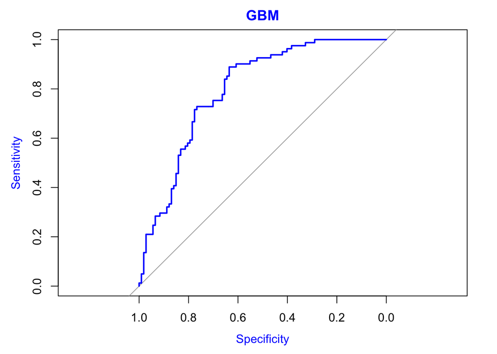

```
##
## Call:
## roc.default(response = test.set$lfp, predictor = gbm.prob[, "yes"],     levels = rev(levels(test.set$lfp)), auc = TRUE, ci = TRUE)
##
## Data: gbm.prob[, "yes"] in 107 controls (test.set$lfp yes) > 81 cases (test.set$lfp no).
## Area under the curve: 0.7989
## 95% CI: 0.7364-0.8614 (DeLong)
```

```r
plot(rocCurve, main="GBM", col="blue", col.main="blue", col.lab="blue")
```

# Help

- The [caret help page](https://topepo.github.io/caret/)
- [Package ’caret](https://cran.r-project.org/web/packages/caret/caret.pdf)
- Kuhn M. 2008. Building predictive models in R using the caret package. J Stat Softw 28:1-26.
- Kuhn M. 2013. [Predictive modeling with R and the caret package](https://www.r-project.org/nosvn/conferences/useR-2013/Tutorials/kuhn/user_caret_2up.pdf). useR! The R User Conference, July 10-12, University of Castilla-La Mancha, Albacete, Spain
- Kuhn M. 2015. [A Short Introduction to the caret Package](https://cran.r-project.org/web/packages/caret/vignettes/caret.pdf).